# Single Cell - Example analysis

Sometimes it’s hard to come up with an obvious filtering cutoff. In this case, adaptive threshold can help us identify points that are more than 3 median absolute deviations (MADs) away from the median in any of the variables we use for QC

```r
# Exclude cells where sum of counts if too loew
th_sum = isOutlier(sce@colData$sum, log = TRUE, type = "lower")
# Exclude cells where total number of detected genes is too low
th_detected = isOutlier(sce@colData$detected, log = TRUE, type = "lower")
# Exclude cells where ERCC percent is too high
th_ercc = isOutlier(sce@colData$altexps_ERCC_percent, log = TRUE, type = "higher")

discarded = th_sum | th_detected | th_ercc # Union of all the logical vectors to create one to rule them all

# Let's see how many we have
DataFrame(
  LibSize=sum(th_sum),
  NExprs=sum(th_detected),
  SpikeProp=sum(th_ercc),
  Total=sum(discarded)
) %>% print()
```

```
## DataFrame with 1 row and 4 columns
##     LibSize    NExprs SpikeProp     Total
##   <integer> <integer> <integer> <integer>
## 1        47        65        96       153
```

All of above could be done in one step XDDDD

```r
reasons <- quickPerCellQC(
  umi_cell,
  sum.field = "sum",
  detected.field = "detected",
  sub.fields=c("altexps_ERCC_percent"))
print(reasons)
```

```
## DataFrame with 864 rows and 4 columns
##         low_lib_size   low_n_features high_altexps_ERCC_percent   discard
##     <outlier.filter> <outlier.filter>          <outlier.filter> <logical>
## 1              FALSE            FALSE                     FALSE     FALSE
## 2              FALSE            FALSE                     FALSE     FALSE
## 3              FALSE            FALSE                     FALSE     FALSE
## 4              FALSE            FALSE                     FALSE     FALSE
## 5              FALSE            FALSE                     FALSE     FALSE
## ...              ...              ...                       ...       ...
## 860            FALSE            FALSE                     FALSE     FALSE
## 861            FALSE            FALSE                     FALSE     FALSE
## 862             TRUE             TRUE                      TRUE      TRUE
## 863            FALSE            FALSE                     FALSE     FALSE
## 864            FALSE            FALSE                     FALSE     FALSE
```

```r
colSums(as.matrix(reasons)) %>% print()
```

```
##              low_lib_size            low_n_features high_altexps_ERCC_percent                   discard
##                        47                        65                       137                       165
```

```r
#              low_lib_size            low_n_features    high_altexps_ERCC_percent                   discard
#                        47                       65                           137                       165
```

So according to these QC metrics we have to discard 165 cells. But let’s store these information in our colData for now, and don’t remove it just yet.

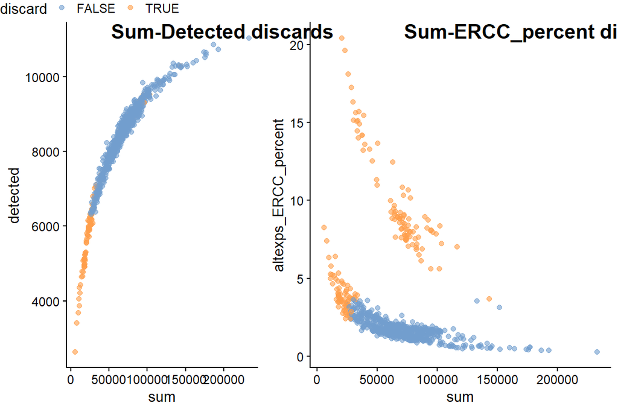

```r
sce$discard <- reasons$discard

# Just plot which cells to discard
# Use scater
s_d = scater::plotColData(sce, x = "sum", y = "detected", colour_by = "discard")
s_perc = scater::plotColData(sce, x = "sum", y = "altexps_ERCC_percent", colour_by = "discard")
ggpubr::ggarrange(s_d, s_perc,
                  labels = c("Sum-Detected discards", "Sum-ERCC_percent discards"),
                  common.legend = T,
                  widths = c(1.5, 2))
```

## Highly expressed genes

Let’s take a look at the most expressed genes in the whole dataset. We will use symbols we obtained using AnnotationDbi.

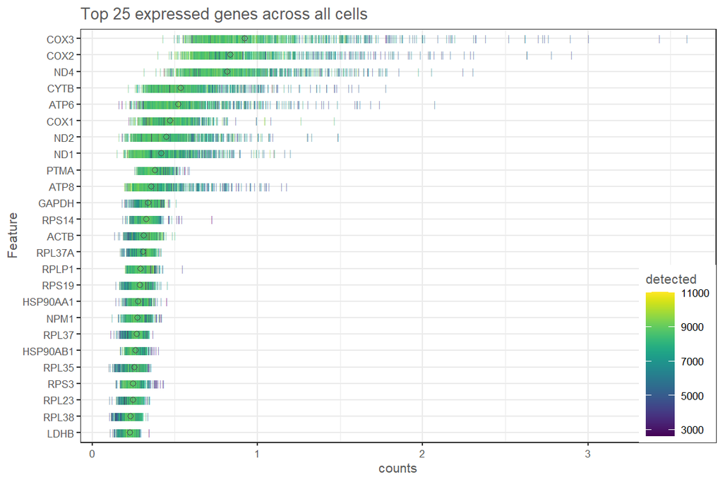

```r
# Use sce, counts assay as the matrix used to get the top expressed genes
# n: how many top genes?
# feature_names_to_plot: NULL - use rownames (it means we use original loaded gene names).
# In this case we passed another column from rowData() specifying gene SYMBOL, fetched using AnnotationDbi.
# colour_cells_by: (colour CELLS, which mean we pass a metadata of cells -> column of colData())
p = plotHighestExprs(sce,
                 n = 25,
                 exprs_values = "counts",
                 feature_names_to_plot = "SYMBOL",
                 colour_cells_by="detected")
p + ggtitle("Top 25 expressed genes across all cells")
```

We see a lot of genes like “RP*..blah” which are ribosomal genes. It’s normal for sc-dataset to containg a lot of ribosomal or mitochondrial genes. Let’s keep the genes which were only detected (expression value > 1) in 2 or more cells. We’ll discard approximately 4,000 weakly expressed genes thanks to this.

```r
# By row to use genes not cells
# Detection_limit = 1 -> Use only genes that have >= 1 read aligned (1 count)

# nexpr function returns number of cells in which genes after above filtering are present
# and we want only genes that are expressed in 2 cells or more -> that's why >=2 is present
keep_feature <- nexprs(sce, byrow = TRUE, detection_limit = 1) >= 2
rowData(sce)$discard <- !keep_feature # Add a 'discard' annotation to each gene (rowData())
print(table(rowData(sce)$discard))
```

```
##
## FALSE  TRUE
## 13873  4205
```

Wow - we have succesfully annotated all cell and marked 4205 as lowly expressed!

# Sensational dimensionality reduction (again)

Let’s create a log2 raw transformed assay now and create a SingleCellExperiment object that will apply previous QC.

```r
assay(sce, "logcounts_raw") <- log2(counts(sce) + 1)
print(sce) # assays(2): counts logcounts
```

```
## class: SingleCellExperiment
## dim: 18078 864
## metadata(0):
## assays(2): counts logcounts_raw
## rownames(18078): ENSG00000187634 ENSG00000188976 ... ENSG00000183753 ENSG00000172352
## rowData names(4): SYMBOL mean detected discard
## colnames(864): NA19098.r1.A01 NA19098.r1.A02 ... NA19239.r3.H11 NA19239.r3.H12
## colData names(12): individual replicate ... total discard
## reducedDimNames(0):
## mainExpName: NULL
## altExpNames(1): ERCC
```

```r
sce.qc = sce[!rowData(sce)$discard, !colData(sce)$discard]
sce.qc
```

```
## class: SingleCellExperiment
## dim: 13873 699
## metadata(0):
## assays(2): counts logcounts_raw
## rownames(13873): ENSG00000187634 ENSG00000188976 ... ENSG00000012817 ENSG00000198692
## rowData names(4): SYMBOL mean detected discard
## colnames(699): NA19098.r1.A01 NA19098.r1.A02 ... NA19239.r3.H11 NA19239.r3.H12
## colData names(12): individual replicate ... total discard
## reducedDimNames(0):
## mainExpName: NULL
## altExpNames(1): ERCC
```

With log-transformation, we equalize the large difference between strongly and weakly expressed genes, and immediately see cells form groups by replicate, individual, and sequencing depth. Proof:

##### PCA on raw counts

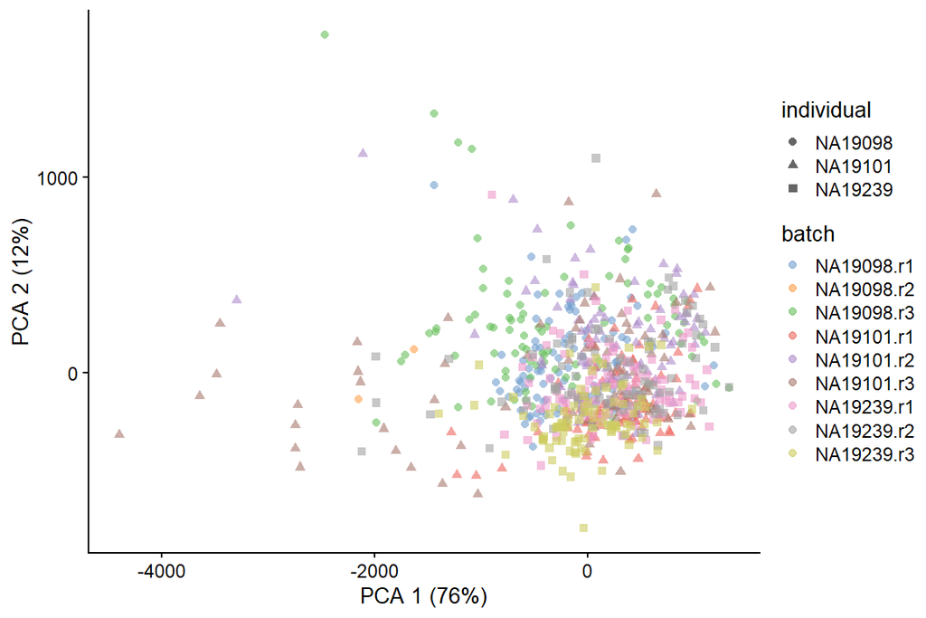

```r
# Again - calculate reduced dim
sce.tmp = scater::runPCA(sce.qc, exprs_values = "counts")
plotPCA(sce.tmp, colour_by = "batch", shape_by = "individual")
```

#####PCA on log-transformed counts

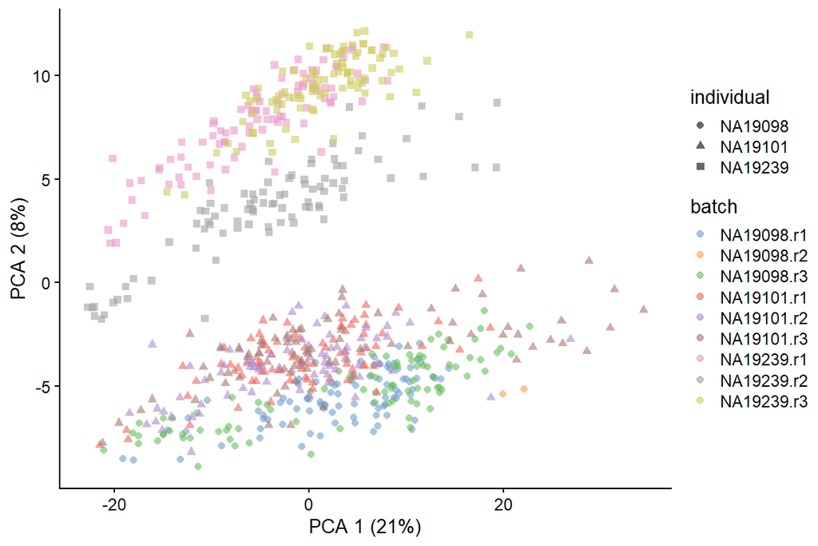

```r
# Again - calculate reduced dim
sce.qc = scater::runPCA(sce.qc, exprs_values = "logcounts_raw")
plotPCA(sce.qc, colour_by = "batch", shape_by = "individual")
```

Clearly log-transformation is benefitial for our data - it reduces the variance on the first principal component and already separates some biological effects. Moreover, it makes the distribution of the expression values more normal. But raw logcounts are not good enough. We should use the logcounts slot (produced by scater) which additionally to log2 normalizes by a lib size. Let’s do it.

```r
# let's use sce for clarity
# from now on `sce` object is the same as `sce.qc` (it has applied quality control)
sce = scater::logNormCounts(sce.qc)
sce # assays(3) counts logcounts_raw logcounts
```

```
## class: SingleCellExperiment
## dim: 13873 699
## metadata(0):
## assays(3): counts logcounts_raw logcounts
## rownames(13873): ENSG00000187634 ENSG00000188976 ... ENSG00000012817 ENSG00000198692
## rowData names(4): SYMBOL mean detected discard
## colnames(699): NA19098.r1.A01 NA19098.r1.A02 ... NA19239.r3.H11 NA19239.r3.H12
## colData names(13): individual replicate ... discard sizeFactor
## reducedDimNames(1): PCA
## mainExpName: NULL
## altExpNames(1): ERCC
```

Let’s run PCA again, this time on logNormCounts

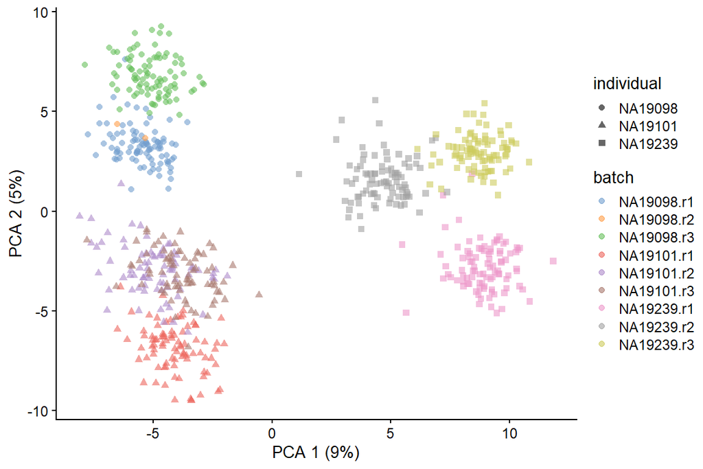

```r
sce = runPCA(sce, exprs_values = "logcounts")
plotPCA(sce, colour_by = "batch", shape_by = "individual")
```

*NOW WE’RE TALKIN’* Let’s do UMAP and tSNE

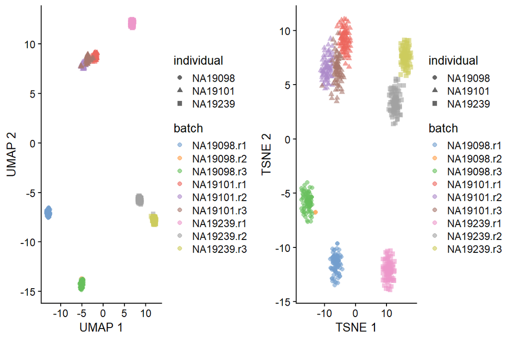

```r
sce = sce %>%
  runTSNE(exprs_values = "logcounts") %>%
  runUMAP(exprs_values = "logcounts")
u = plotUMAP(sce, colour_by = "batch", shape_by = "individual")
t = plotTSNE(sce, colour_by = "batch", shape_by = "individual")
ggpubr::ggarrange(u, t)
```

## Other steps (skipped) We could do a couple of other steps also like: 1. Analyze correlations with PCs 2. Analyze and plot some explenatory variables 3. blah…blah…blah

> In other words we can search for “Confounding Factors”. For the *sake of teacher, other students and my mental health* I’ll skip that in this project. Let’s do something more fun.

# Biological analysis

## Clustering

```r
# Even more libs
library(SC3)

# sc3() requires rowData() to have a column named 'feature_symbol' so create it
rowData(sce)$feature_symbol = rowData(sce)$SYMBOL # just copy existing
# Biology =T, kse = 3 (biology: dont add additional metadata to use with other plotting functions, kse: number of clusters)
sce.clus = sc3(sce, ks = 3, biology = T, n_cores = 4)
```

```
## Setting SC3 parameters...
```

```
## Calculating distances between the cells...
```

```
## Performing transformations and calculating eigenvectors...
```

```
## Performing k-means clustering...
```

```
## Calculating consensus matrix...
```

```
## Calculating biology...
```

```r
sce.clus
```

```
## class: SingleCellExperiment
## dim: 13873 699
## metadata(1): sc3
## assays(3): counts logcounts_raw logcounts
## rownames(13873): ENSG00000187634 ENSG00000188976 ... ENSG00000012817 ENSG00000198692
## rowData names(10): SYMBOL mean ... sc3_3_markers_auroc sc3_3_de_padj
## colnames(699): NA19098.r1.A01 NA19098.r1.A02 ... NA19239.r3.H11 NA19239.r3.H12
## colData names(15): individual replicate ... sc3_3_clusters sc3_3_log2_outlier_score
## reducedDimNames(3): PCA TSNE UMAP
## mainExpName: NULL
## altExpNames(1): ERCC
```

## Plot PCA with cluster annotation

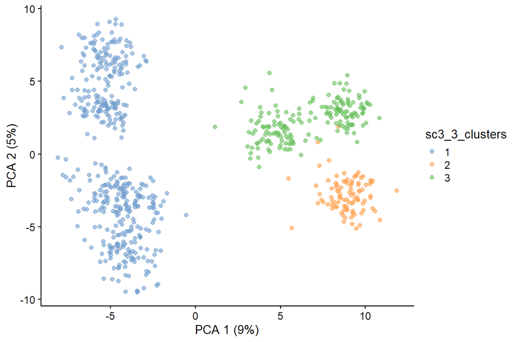

```r
plotPCA(sce.clus, colour_by = "sc3_3_clusters")
```

## Plot consensus map

> It represents similarity between the cells based on the averaging of clustering results from all combinations of clustering parameters. Similarity 0 (blue) means that the two cells are always assigned to different clusters. In contrast, similarity 1 (red) means that the two cells are always assigned to the same cluster.

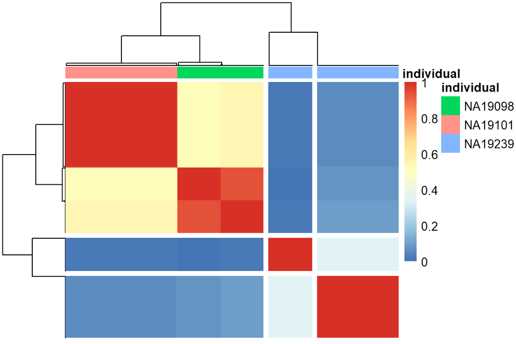

```r
sc3_plot_consensus(
    sce.clus, k = 3,
    show_pdata = c(
        "individual"
    )
)
```

## Plot DE genes

[figure not shown]

```r
# https://github.com/hemberg-lab/SC3/issues/84
# When having rownames as ensembl ids (non unique) there are errors
# idk why
# but
# lets convert

rownames(sce.clus) = rowData(sce.clus)$feature_symbol

sc3_plot_de_genes(
  sce.clus,
  k = 3,
  show_pdata = c(
        "individual"
    ))
```

## Plot markers

> To find marker genes, for each gene a binary classifier is constructed based on the mean cluster expression values. The classifier prediction is then calculated using the gene expression ranks. The area under the receiver operating characteristic (ROC) curve is used to quantify the accuracy of the prediction. A p-value is assigned to each gene by using the Wilcoxon signed rank test. By default the genes with the area under the ROC curve (AUROC) > 0.85 and with the p-value < 0.01 are selected and the top 10 marker genes of each cluster are visualized in this heatmap.

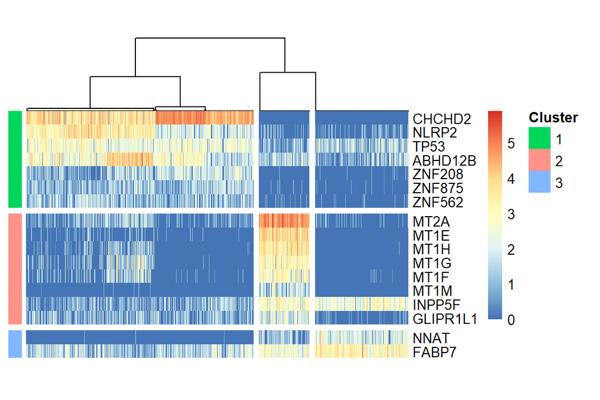

```r
sc3_plot_markers(sce.clus, k = 3)
```